[figure not shown]

### ESS 575 Models for Ecological Data

#### Influence of source diversity on colonization success:

##### A manipulative field experiment incorporating spatial-autocorrelation

#### April 21, 2017

#### Table of Contents

I. Motivation

II. Problem

III. Preliminaries

IV. Calibration model

V. Hierarchical model

VI. References

#### I. Motivation

Many graduate students at CSU perform designed experiments to understand causation. We often turn to ANOVAs or ANCOVAs to analyze the effects of treatments in these experiments. The Bayesian methods you have learned in this class can be usefully applied to these problems. We often need the Bayesian approach to account for errors in reponses, to deal with group level effects, and, as illustrated here, to deal with spatial autocorrelation. This lab provides illustrates the analysis of a designed experiment with a data model for an unobserved state and continuous spatial depdence in the data.

#### II. Problem

We will analyze the importance of source diversity on the colonization success of *Bromus tectorum* (cheatgrass) founding populations in a common garden in Colorado. An experiment manipulated the number of geographically distinct sources represented in experimental populations of 32 cheatgrass seeds (5 levels of diversity: 1, 2, 4, 8, 16 sources represented; hereafter: **source diversity**). The objective of the experiment was to determine if the strength of the diversity effect would vary if seeds were pre-adapted to the common garden. To do this, experimental plots were composed of seeds from Colorado or Nevada (hereafter: **source region**) across all diversity treatments; Colorado representing the “pre-adapted” treatment and Nevada the “unadapted” one.

#### III. Preliminaries

We need to compose two separate models to understand the effect of source diversity and source region on the colonization success of our experimental populations. The response variable of interest is the number of seeds produced, which will give us an idea of how many individuals could establish in the following generation. Unfortunately, we only have data on the total seed biomass because there were far too many seeds to count. Thus, the first model we need to construct is a **calibration model** explaining the relationship between seed count and seed weight. We will then use parameters from this model to inform priors in our Bayesian regression model assessing the importance of source region and diversity on colonization success (number of seeds produced per population).

You will need install the packages `ade4` and `matrixStats`.

#### IV. Calibration model

To inform the calibration model, we counted and weighed seeds from a subset of experimental plots (see *calibration* data set).

1. We have written the likelihood for the relationship between seed count and seed weight, where seed weight is the response of interest. As seed weight can only be positive, it is lognormally distributed. We assume a linear relationship between seed weight and seed count with an intercept that crosses zero (*i.e.* there is no intercept parameter, just a slope).

$$\text{log}(w_i) \sim \text{normal}(\text{log}(\alpha_c x_{c,i}), \sigma^2_c)$$

2. We have also provided code for the simple calibration model. This will be helpful in developing the hierarchical regression model. Make sure you understand the different parts of the code.

```r
library(rjags)
calib <- read.csv("/Users/Tom/Documents/EcologicalModelingCourse/_A_Master_Lab_Exercises/ContinuousSpatialProcesses/SeedCt_subset_model.csv")
y_wt <- calib$wt
x_ct <- calib$ct

# because seed count is high, we model the relationship between weight and
# hundreds of seeds

data = list(
  y_lnwt = log(y_wt),
  x_ct = x_ct / 100,
  n = length(calib$wt))


  inits = list(
  list(alpha = 0, tau = 0.01),
  list(alpha = 1, tau = 0.5)
  )
```

```r
#### Calibration model
{
sink("calibration_model_jags.R")
cat("
model{

  ### priors
  tau ~ dgamma(0.001, 0.001)
  alpha ~ dnorm(0, 1e-4)

  # derived quantities
  sd2 <- 1 / tau

  ### likelihood

  # because we are taking the log of the product alpha*x_ct, we need to restrict values to be
  # positive. by looping through all values and choosing the maximum between a very small number positive
  # number and each alpha*x_c[i], we restrict all values to be non-zero and positive

   for (i in 1:n){
     mu[i] <- max(1e-10, x_ct[i] * alpha)
   }

  # remember, y_lnwt is already log-transformed
  for (i in 1:n){
    y_lnwt[i] ~ dnorm(log(mu[i]), tau)
  }


  }# end model

",fill=TRUE)
sink()
}
```

```r
n.adapt=2000
n.update=5000
n.iter= 5000

jm.cal = jags.model(file="calibration_model_jags.R", data=data, n.adapt = n.adapt, inits=inits, n.chains=length(inits))
```

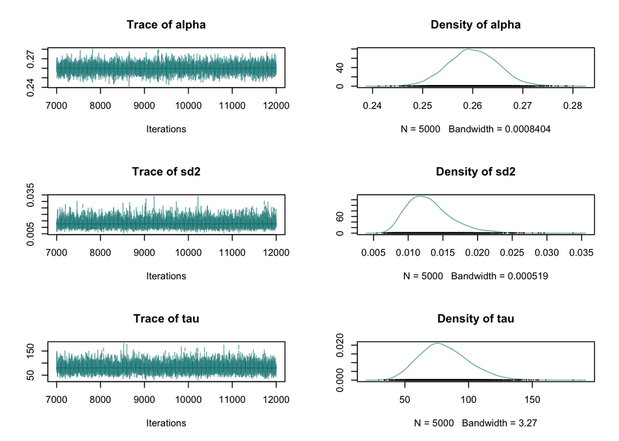

```r
update(jm.cal, n.iter = n.update)
zc.cal = coda.samples(jm.cal, variable.names = c("alpha", "tau", "sd2"), n.iter=n.iter)
zj.cal = jags.samples(jm.cal, variable.names = c("alpha", "tau", "sd2"), n.iter=n.iter)

plot(zc.cal, col = rgb(0, 0.5, 0.5, 0.6))
```

```r
summary(zc.cal)
```

```
##
## Iterations = 7001:12000
## Thinning interval = 1
## Number of chains = 2
## Sample size per chain = 5000
##
## 1. Empirical mean and standard deviation for each variable,
##    plus standard error of the mean:
##
##           Mean        SD  Naive SE Time-series SE
## alpha  0.26006  0.005002 5.002e-05      5.603e-05
## sd2    0.01305  0.003304 3.304e-05      3.489e-05
## tau   81.30642 19.617990 1.962e-01      2.037e-01
##
## 2. Quantiles for each variable:
##
##           2.5%     25%      50%      75%     97.5%
## alpha  0.25035  0.2567  0.25999  0.26346   0.26999
## sd2    0.00811  0.0107  0.01258  0.01484   0.02101
## tau   47.60653 67.4021 79.49182 93.48398 123.30505
```

```r
gelman.diag(zc.cal)
```

```
## Potential scale reduction factors:
##
##       Point est. Upper C.I.
## alpha          1          1
## sd2            1          1
## tau            1          1
##
## Multivariate psrf
##
## 1
```

3. What is $\sigma^2_c$? Does this matter for understanding the relationship between seed weight and count?
4. In the hierarchical model below, we will parameterize $\alpha_c$ and $\tau_c$ using an *informed* gamma prior using values from this calibration experiment. Write an R function using the means and standard deviations of the marginal posterior distributions of $\alpha_c$ and $\tau_c$ found here, to calculate the shape and rate parameters of a gamma distribution. Save these as objects– you will need them for the next model.

```r
# extract mean and sd of alpha
mu_alpha <- mean(zj.cal$alpha)
sd_alpha <- sd(zj.cal$alpha)

mu_tau <- mean(zj.cal$tau)
sd_tau <- sd(zj.cal$tau)

# moment-matching for informed prior
gamma<- function (mn, sd){
  a = mn ^2 / sd^2
  b= mn / sd^2
  return(c(a, b))
}

gamma(mu_alpha, sd_alpha)
```

```
## [1]  2703.452 10393.412
```

```r
# 2614.373 10054.346

gamma(mu_tau, sd_tau)
```

```
## [1] 16.8374266  0.2071145
```

```r
# 17.183387  0.211654
```

### V. Hierarchical model

We are interested in how source diversity and source region influence the population-level production of cheatgrass seeds. The observed data, $y_i$, are the seed biomass of each experimental population. We want to understand how the number of seeds produced per population responds to the diversity treatment, and their interaction.

We have the following design matrix: 1. Column one contains 1s. 2. Column two contains diversity of plot $i$ (1, 2, 4, 8, or 16). 3. Column three contains the region for plot $i$ (1 if Nevada and 0 otherwise) 4 Column 4 is the product of diversity and region.

The response, $y_i$ is the observed count in plot $i$ divided by 100, i.e. the units of $y$ are 100’s of seeds. You may reasonably treat “counts” as a continuous random variable because the observations in each plot number in the 10,000s. Compose a deterministic model that includes an intercept and the effects of diversity, region, and their interaction.

1. Draw a DAG and write the posterior and joint distribution for the observed and unobserved quantities. Your model will include:
- A data model relating the observed biomass to unobserved seed “counts”.
- A process model that relates “counts,” to the parameters in the deterministic model and the design matrix. Assume that there is continuous spatial dependence among the plots that must be modeled. You may assume that unstructured variance = 0 because there is no measurement error or fine-scaled heterogeneity at the plot scale.

$$\begin{align}
\Sigma_{i,j} &= \sigma^2_p e^{(-D_{i,j}\phi)}\\
[\phi,\sigma_p^2,\boldsymbol {\beta},\alpha,\sigma^2_c \mid \mathbf y] & \propto \prod_{i=1}^n[y_i\mid \alpha z_i,\sigma^2_c][\mathbf z\mid \mathbf X \boldsymbol \beta, \boldsymbol \Sigma][\boldsymbol \beta,\sigma^2_p,\sigma^2_c,\phi]\\
\text{log}(y_i) & \sim \text{normal}(\text{log}(\alpha_c z_i), \sigma^2_c)\\
\text{log}(\mathbf{z}) & \sim \text{multivariate normal}(\text{log}(\mathbf{X})\boldsymbol \beta, \Sigma)\\
&\text{with appropriate priors on parameters}
\end{align}$$

2. Rather than blindly accept that points are spatially autocorrelated, you should run a Mantel Test before you build your model to discover that there is autocorrelation that must be accounted for. To do this, first, create a distance matrix using the `dist()` function in R. The only argument you will need to provide is two joined columns of ‘east’ and ‘north’ from the main data set (these represent distances east and north from a corner of the common garden). Then create a second matrix using the observed seed biomass data, ‘seeds’. Inspect the matrices using `as.matrix()`. Use the `mantel.rtest()` function in the `ade4` library (you will need to install and load this) to test for spatial autocorreltation in the data. Remember, all this indicates is that your model will need to account for auto-correlation in the residuals.

What do these matrices represent? What is this test actually doing? Interpret your results.

```r
brte_sub <- read.csv("/Users/Tom/Documents/EcologicalModelingCourse/_A_Master_Lab_Exercises/ContinuousSpatialProcesses/brte_labdata1.csv")

distance <- 0.75
brte_sub$east <- brte_sub$row * distance
brte_sub$north <- brte_sub$col * distance

pop.dists <- dist(cbind(brte_sub$east, brte_sub$north))
seeds.dists <- dist(brte_sub$seeds)

as.matrix(pop.dists)[1:5,1:5]
```

```
##           1        2         3         4         5
## 1  0.000000 12.36932  3.824265  6.046693  4.373214
## 2 12.369317  0.00000 12.772040 15.167811 15.767847
## 3  3.824265 12.77204  0.000000  2.704163  3.354102
## 4  6.046693 15.16781  2.704163  0.000000  3.092329
## 5  4.373214 15.76785  3.354102  3.092329  0.000000
```

```r
as.matrix(seeds.dists)[1:5,1:5]
```

```
##        1      2      3      4      5
## 1  0.000 22.295 39.608 19.878 23.479
## 2 22.295  0.000 17.313  2.417  1.184
## 3 39.608 17.313  0.000 19.730 16.129
## 4 19.878  2.417 19.730  0.000  3.601
## 5 23.479  1.184 16.129  3.601  0.000
```

```r
library(ade4)
Mantel <- mantel.rtest(pop.dists, seeds.dists)
```

Remember that Bayesians don’t mix freuquentist with Bayesian analyses in the same paper. However, the Mantel test is a convenient way to evaluate if auto-correlation exists. An alternative would be to plot a semivariogram of the data, i.e, the semivariance vs the distance. This can be done without computing residuals using the plot function in the `geoR` package.

The covariance matrix in the process model will use the first distance matrix you created, $\mathbf{D}$, such that
$$\Sigma_{i,j} = \sigma^2_p e^{(-D_{i,j}\phi)}$$

Now let’s put it all together. We have a likelihood relating the observed biomass data, $y_i$, to the latent variable of seed number (in hundreds of seeds), $z_i$, that is parameterized using information from the calibration experiment. Seed number can be explained by a regression model using covariates of source diversity, source region, and their interaction, where observations of seed number covary based on their location in the common garden.

We will provide you will initial values to guide you in setting up the full model.

```r
# create model matrix with div, loc, an interaction between div and loc, as covariates
# this shows you the covariate values for each observation

X.1 = model.matrix( ~ gen + loc + gen:loc, data=brte_sub)

# Define data
lny = as.double(log(brte_sub$seeds))
X = cbind(as.double(X.1[,1]), scale(as.double(X.1[,2])),
           scale(as.double(X.1[,3])), scale(as.double(X.1[,4])))
D = as.matrix(pop.dists) # first distance matrix
n = length(lny) # number of observations

data = list(
  y = lny,
  X = X,
  n = n,
  D = D,
  p=dim(X)[2] # tells us how many betas there are
)

# Define initial conditions
inits <- list(
  list(beta = c(1, 1, 1, 1), tau.p = 0.1, phi = 1, alpha.c = 0.25, tau.c = 81),
  list(beta = c(1.5, 1.5, 1.5, 1.5), tau.p = 1, phi = 2, alpha.c = 0.23, tau.c = 85)
)
```

3. Build and fit the hierarchical model to the experimental data in JAGS. We highly suggest using a small number of iterations as you are getting started with this model (it took 5 minutes to initialize, update, and make coda samples using n.adapt = 250, n.update = 500, n.iter = 1000). Once you get the model running with results that seem reasonable, then you can up your iterations. Some hints:
- You will need to use `dmvnorm()` for the distribution of $\mathbf {z}$. Rather than looping over *i* values of $\mathbf z$, keep the mean and response as a vector. As with `dnorm()`, the variance component needs to be in the form of precision. To do this, take the inverse of your covariance matrix using `inverse()`.
- Create an object for the sum of your covariates multiplied by their respective $\beta$ ’s. We can call this vector $u$ and can create it using matrix multiplication in JAGS: $u = \mathbf{X}$ %*% $\boldsymbol{\beta}$.
- You might need to restrict values to be greater than zero before they pass through a log() argument. Use the trick in the calibration model above to do this.
- Keep $z$ log-transformed throughout the model. Remember than log(a*b) = log(a) + log(b). This should help in the likelihood.

As always, include code for posterior predictive checks.

```r
{
sink("brte_model_jags.R")
cat("
 model{
  ## priors
  # vague priors
  tau.p ~ dgamma(0.001, 0.001)
  sigmasq.p <- 1 / tau.p
  phi ~ dunif(1e-10, 5)
  for(i in 1:p){
     beta[i]~dnorm(0,0.0001)
   }

  # informed priors
   tau.c  ~ dgamma(17.1841127, 0.2118985)
   alpha.c ~ dgamma(2505.777, 9639.005)


  ## create covariance matrix
  # account for spatial autocorrelation using a covariance matrix specified by
  # distance matrix (D), structured variance (sigma.p.str^2), and Matern variable (phi)

   for(i in 1:n){
     for(j in 1:n){
       Cov.mat[i,j]<-sigmasq.p^2*exp(-D[i,j]*phi)
     }
   }

  # invert covariance matrix to obtain precision matrix (use in multivariate normal)
    Prec.mat <- inverse(Cov.mat)

  # mean number of seeds governed by beta priors and covariates
    mu <- X%*%beta

  # restrict mu to be positive  (or you could exponentiate)
   for (i in 1:n){
     mu.pos[i]<- max(0.00000001, mu[i])
   }

  # multivariate lognormal (all positive values of seed number) with precision matrix
   lnz ~ dmnorm(log(mu.pos), Prec.mat)

  # likelihood (data conditioned on log(alpha.c*z[i]) which is the same as
  # log(alpha.c) + log(z[i])
    for (i in 1:n){
      y[i] ~ dnorm(log(alpha.c) + lnz[i], tau.c)
      y.new[i] ~ dnorm(log(alpha.c) + lnz[i], tau.c)

      # squared residuals for model fit
      sq.y[i] <- (y[i] - (log(alpha.c) + lnz[i])) ^ 2
      sq.ynew[i] <- (y.new[i] - (log(alpha.c) + lnz[i])) ^ 2
    }
      # posterior predictive check

      # sum of squared residuals (from above) for model fit
      sumsq.y <- sum(sq.y[])
      sumsq.ynew <- sum(sq.ynew[])
      p.sumsq <- step(sumsq.ynew - sumsq.y)

 }
",fill=TRUE)
sink()
}
```

```r
n.adapt = 10
n.update = 50
n.iter = 100

# initialize model with 2 chains
jm.hier = jags.model(file="brte_model_jags.R", data=data, n.adapt = n.adapt, inits=inits, n.chains=length(inits))
update(jm.hier, n.iter = n.update)
zc.hier = coda.samples(jm.hier, variable.names = c("beta", "alpha.c", "tau.c", "tau.p", "phi", "p.sumsq"), n.iter=n.iter)
```

```
## NOTE: Stopping adaptation
```

```r
zj.hier = jags.samples(jm.hier, variable.names = c("beta", "alpha.c", "tau.c", "tau.p", "phi", "p.sumsq"), n.iter=n.iter)

# posterior predictive check
mean(zj.hier$p.sumsq)
```

```
## [1] 0.485
```

4. Plot the marginal posterior distributions for $\beta_0$, $\beta_\text{diversity}$, $\beta_\text{region}$, $\beta_\text{diversity*region}$, $\sigma^2_p$, $\sigma^2_c$, $\alpha^2_c$, and $\phi$. Overlay lines to show 95% credible intervals. Interpret your results: How do source diversity and region influence colonization success of *B. tectorum* founding populations?

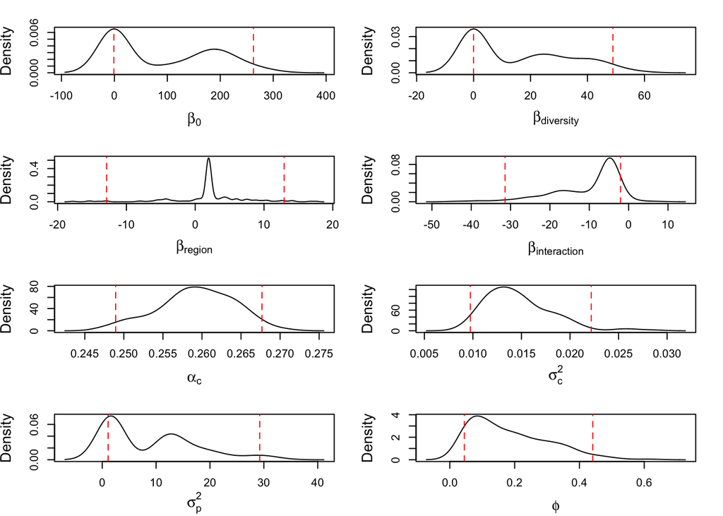

```r
par(mar=c(4,4,2,2), mfrow=c(4,2))

# beta_0
plot(density(zj.hier$beta[1,,]), main = "", xlab=expression(beta[0]), cex.lab =1.3)
abline(v=quantile(zj.hier$beta[1,,], c(0.025, 0.975)), col = "red", lty = "dashed")

# beta_1 (diversity)
plot(density(zj.hier$beta[2,,]), main = "", xlab=expression(beta["diversity"]), cex.lab =1.3)
abline(v=quantile(zj.hier$beta[2,,], c(0.025, 0.975)), col = "red", lty = "dashed")

# beta_2 (region)
plot(density(zj.hier$beta[3,,]), main = "", xlab=expression(beta["region"]), cex.lab =1.3)
abline(v=quantile(zj.hier$beta[3,,], c(0.025, 0.975)), col = "red", lty = "dashed")

# beta_3 (interaction)
plot(density(zj.hier$beta[4,,]), main = "", xlab=expression(beta["interaction"]), cex.lab =1.3)
abline(v=quantile(zj.hier$beta[4,,], c(0.025, 0.975)), col = "red", lty = "dashed")

# alpha_c
plot(density(zj.hier$alpha.c), main = "", xlab=expression(alpha[c]), cex.lab =1.3)
abline(v=quantile(zj.hier$alpha.c, c(0.025, 0.975)), col = "red", lty = "dashed")

# sigma^2_c
plot(density(1/zj.hier$tau.c), main = "", xlab=expression(sigma[c]^2), cex.lab =1.3)
abline(v=quantile(1/zj.hier$tau.c, c(0.025, 0.975)), col = "red", lty = "dashed")

# sigma^2_p
plot(density(1/zj.hier$tau.p), main = "", xlab=expression(sigma[p]^2), cex.lab =1.3)
abline(v=quantile(1/zj.hier$tau.p, c(0.025, 0.975)), col = "red", lty = "dashed")

# phi
plot(density(zj.hier$phi), main = "", xlab=expression(phi), cex.lab =1.3)
abline(v=quantile(zj.hier$phi, c(0.025, 0.975)), col = "red", lty = "dashed")
```

5. Make a graph with distance on the x-axis as covariance on the y-axis, using the exponential distance equation for which we used to create the covariance matrix. Plot the mean with 95% credible intervals. What does this tell you about the spatial autocorrelation if plots were 0.75m apart in the common garden?

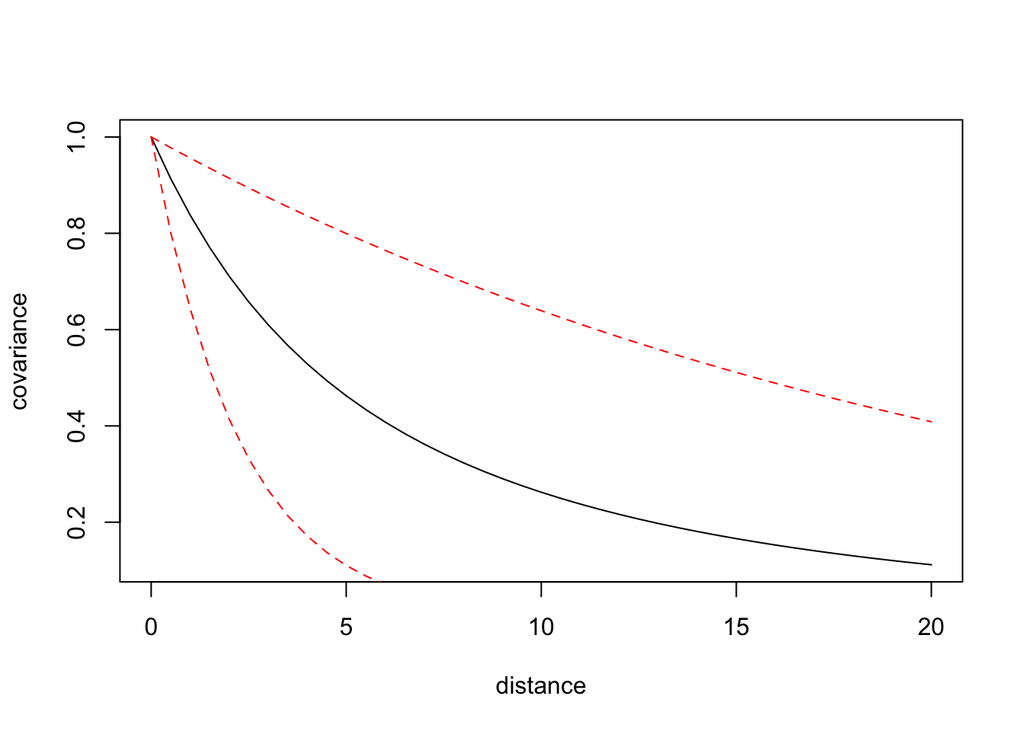

```r
distance <- seq(0, 20, 0.5)
covar <- function(phi, d){
  cov <- exp(-d * phi)
  return(cov)
}

y <- matrix(nrow = length(zj.hier$phi), ncol = length(distance))

for (i in 1:length(zj.hier$phi)){
  y[i,] <- covar(phi = zj.hier$phi[i], d = distance)
}

par(mfrow=c(1,1))
plot(distance, colMeans(y), type = "l", ylab = "covariance")
library(matrixStats)
ci <- colQuantiles(y, probs = c(0.025, 0.975))
lines(distance, ci[,1], col = "red", lty = "dashed")
lines(distance, ci[,2], col = "red", lty = "dashed")
```

Plots that are less than 10 meters apart covary at least somewhat. Plots that are within ~4 meters of each other covary considerably.

### VI. References

Ahlroth P, Alatalo RV, Holopainen A, Kumpulainen T, Suhonen J (2003) Founder population size and number of source populations enhance colonization success in waterstriders. *Oecologia* 137:617-620.

Elam DR, Ridley CE, Goodell K, Ellstrandt NC (2007) Population size and relatedness affect fitness of a self-incompatible invasive plant. *P Natl Acad Sci USA* 104:549-552.

MacArthur RH, Wilson EO (1967) The theory of island biogeography. Princeton University Press, Princeton, NJ.

Mayr E (1965) The nature of colonization in birds. Pages 29-47 in HG Baker and GL Stebbins, editors. The genetics of colonizing species. Academic Press, New York.

Lockwood JL, Cassey P, Blackburn T (2005) The role of propagule pressure in explaining species invasions. *Trends Ecol Evol* 20:223-228.

Simberloff D (2009) The role of propagule pressure in biological invasions. *Annu Rev Ecol Syst* 40:81-102.